# The structural stability of nested experimental plankton system

## nonlinear least squares

We first use the nonlinear least squares method to estimate the parameters.

3 parameters:

```r
df_N_t_2 <- Npulse_sum[["1"]][["D1_2"]][c("day","Fix_Area_recalc")]
fit2 <- nls(
  Fix_Area_recalc ~ K / (1 + A * exp(-r * day )),
  data = df_N_t_2,
  start = list(
    K = 42000,
    r = 0.5,
    A = -0.45
    ),
  control = nls.control(maxiter = 100, warnOnly = TRUE)
)

df_N_t_5 <- Npulse_sum[["1"]][["D1_5"]][c("day","Fix_Area_recalc")]
fit5 <- nls(
  Fix_Area_recalc ~ K / (1 + A * exp(-r * day )),
  data = df_N_t_5,
  start = list(
    K = 310000,
    r = 0.36,
    A = 5.2
    ),
  control = nls.control(maxiter = 100, warnOnly = TRUE)
)

df_N_t_8 <- Npulse_sum[["1"]][["D1_8"]][c("day","Fix_Area_recalc")]
fit8 <- nls(
  Fix_Area_recalc ~ K / (1 + A * exp(-r * day )),
  data = df_N_t_8,
  start = list(
    K = 1400000,
    r = 0.9,
    A = 65
    ),
  control = nls.control(maxiter = 100, warnOnly = TRUE)
)
coeff_pulse <- rbind(coef(fit2),coef(fit5),coef(fit8))
coeff_pulse
```

```
              K         r          A
[1,]   5215.622 0.5079697 -0.4557603
[2,]  39175.577 0.3614746  5.2230213
[3,] 177963.965 0.9050188 67.8913708
```

```r
summary(fit2)
```

```
Formula: Fix_Area_recalc ~ K/(1 + A * exp(-r * day))

Parameters:
    Estimate Std. Error t value Pr(>|t|)
K 5215.62184  170.11494  30.659  0.00106 **
r    0.50797    0.11304   4.494  0.04612 *
A   -0.45576    0.02048 -22.250  0.00201 **
---
Signif. codes:  0 ‘***’ 0.001 ‘**’ 0.01 ‘*’ 0.05 ‘.’ 0.1 ‘ ’ 1

Residual standard error: 191.7 on 2 degrees of freedom

Number of iterations to convergence: 5
Achieved convergence tolerance: 1.674e-06
```

```r
summary(fit5)
```

```
Formula: Fix_Area_recalc ~ K/(1 + A * exp(-r * day))

Parameters:
   Estimate Std. Error t value Pr(>|t|)
K 3.918e+04  6.798e+03   5.763   0.0288 *
r 3.615e-01  7.626e-02   4.740   0.0417 *
A 5.223e+00  9.090e-01   5.746   0.0290 *
---
Signif. codes:  0 ‘***’ 0.001 ‘**’ 0.01 ‘*’ 0.05 ‘.’ 0.1 ‘ ’ 1

Residual standard error: 1245 on 2 degrees of freedom

Number of iterations to convergence: 4
Achieved convergence tolerance: 5.103e-06
```

```r
summary(fit8)
```

```
Formula: Fix_Area_recalc ~ K/(1 + A * exp(-r * day))

Parameters:
   Estimate Std. Error t value Pr(>|t|)
K 1.780e+05  7.550e+03  23.570   0.0018 **
r 9.050e-01  1.032e-01   8.769   0.0128 *
A 6.789e+01  2.762e+01   2.458   0.1332
---
Signif. codes:  0 ‘***’ 0.001 ‘**’ 0.01 ‘*’ 0.05 ‘.’ 0.1 ‘ ’ 1

Residual standard error: 4783 on 2 degrees of freedom

Number of iterations to convergence: 5
Achieved convergence tolerance: 2.352e-06
```

```r
fit2_l <- nls(
  Fix_Area_recalc ~ K / (1 + (K/df_N_t_2$Fix_Area_recalc[1] - 1) * exp(-r * day )),
  data = df_N_t_2,
  start = list(
    K = 41000,
    r = 0.5
    ),
  control = nls.control(maxiter = 100, warnOnly = TRUE)
)

fit5_l <- nls(
  Fix_Area_recalc ~ K / (1 + (K/df_N_t_5$Fix_Area_recalc[1] - 1) * exp(-r * day )),
  data = df_N_t_5,
  start = list(
    K = 350000,
    r = 0.3
    ),
  control = nls.control(maxiter = 100, warnOnly = TRUE)
)

fit8_l <- nls(
  Fix_Area_recalc ~ K / (1 + (K/df_N_t_8$Fix_Area_recalc[1] - 1) * exp(-r * day )),
  data = df_N_t_8,
  start = list(
    K = 1400000,
    r = 0.9
    ),
  control = nls.control(maxiter = 100, warnOnly = TRUE)
)
coeff_pulse_l <- rbind(coef(fit2_l),coef(fit5_l),coef(fit8_l))
coeff_pulse_l
```

```
             K           r
[1,] 223951.10 -0.07770653
[2,]  44746.51  0.29877416
[3,] 192622.86  0.69485278
```

```r
coeff_pulse
```

```
              K         r          A
[1,]   5215.622 0.5079697 -0.4557603
[2,]  39175.577 0.3614746  5.2230213
[3,] 177963.965 0.9050188 67.8913708
```

```r
coeff_pulse_l
```

```
             K           r
[1,] 223951.10 -0.07770653
[2,]  44746.51  0.29877416
[3,] 192622.86  0.69485278
```

```r
summary(fit2_l)
```

```
Formula: Fix_Area_recalc ~ K/(1 + (K/df_N_t_2$Fix_Area_recalc[1] - 1) *
    exp(-r * day))

Parameters:
    Estimate Std. Error t value Pr(>|t|)
K  2.240e+05  2.933e+07   0.008    0.994
r -7.771e-02  3.627e-01  -0.214    0.844

Residual standard error: 1560 on 3 degrees of freedom

Number of iterations till stop: 32
Achieved convergence tolerance: 7.503
Reason stopped: 算法的步因素0.000488281的大小被减少到小于0.000976563的'minFactor'值
```

```r
summary(fit5_l)
```

```
Formula: Fix_Area_recalc ~ K/(1 + (K/df_N_t_5$Fix_Area_recalc[1] - 1) *
    exp(-r * day))

Parameters:
   Estimate Std. Error t value Pr(>|t|)
K 4.475e+04  9.524e+03   4.698  0.01824 *
r 2.988e-01  4.239e-02   7.048  0.00587 **
---
Signif. codes:  0 ‘***’ 0.001 ‘**’ 0.01 ‘*’ 0.05 ‘.’ 0.1 ‘ ’ 1

Residual standard error: 1249 on 3 degrees of freedom

Number of iterations to convergence: 8
Achieved convergence tolerance: 5.27e-06
```

```r
summary(fit8_l)
```

```
Formula: Fix_Area_recalc ~ K/(1 + (K/df_N_t_8$Fix_Area_recalc[1] - 1) *
    exp(-r * day))

Parameters:
   Estimate Std. Error t value Pr(>|t|)
K 1.926e+05  1.364e+04   14.12 0.000770 ***
r 6.948e-01  3.721e-02   18.68 0.000335 ***
---
Signif. codes:  0 ‘***’ 0.001 ‘**’ 0.01 ‘*’ 0.05 ‘.’ 0.1 ‘ ’ 1

Residual standard error: 7732 on 3 degrees of freedom

Number of iterations to convergence: 6
Achieved convergence tolerance: 5.035e-06
```

```r
plot(df_N_t_5$day, df_N_t_5$Fix_Area_recalc)
curve( coef(fit5)[["K"]] / (1 + coef(fit5)[["A"]] * exp(- coef(fit5)[["r"]] * x )),
      add = TRUE, lwd = 2, col = "blue")
```

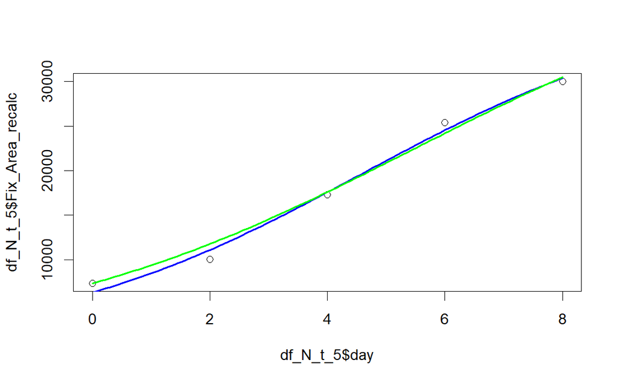

```r
curve( coef(fit5_l)[["K"]] / (1 + (coef(fit5_l)[["K"]]/df_N_t_5$Fix_Area_recalc[1] - 1) * exp(- coef(fit5_l)[["r"]] * x )),
      add = TRUE, lwd = 2, col = "green")
```

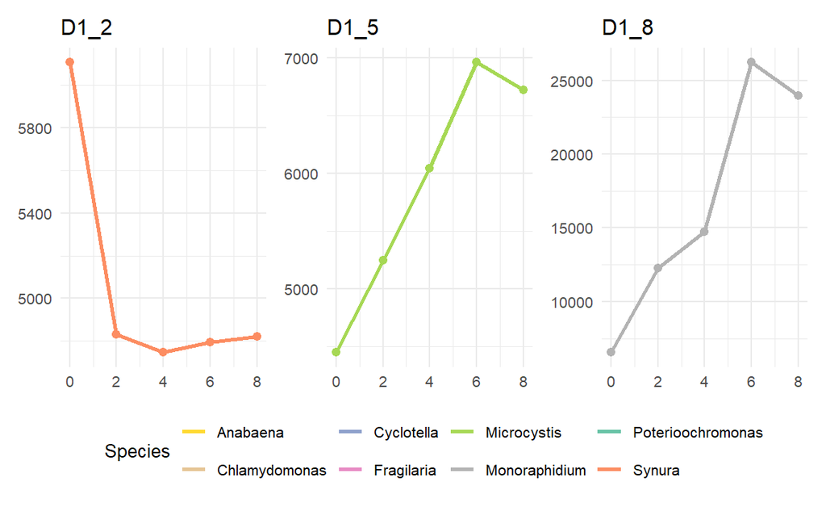

```r
(Nlimited_sumplots[["1"]][["D1_2"]]|Nlimited_sumplots[["1"]][["D1_5"]]|Nlimited_sumplots[["1"]][["D1_8"]])+
plot_layout(guides = 'collect') &
  theme(legend.position = "bottom")
```

```r
d_N_t_2 <- Nlimited_sum[["1"]][["D1_2"]][c("day","Fix_Area_recalc")]
fit_limit2 <- nls(
  Fix_Area_recalc ~ K / (1 + A * exp(-r * day )),
  data = d_N_t_2,
  start = list(
    K = 38000,
    r = 1.6,
    A = -0.22
    ),
  control = nls.control(maxiter = 100, warnOnly = TRUE)
)
d_N_t_5 <- Nlimited_sum[["1"]][["D1_5"]][c("day","Fix_Area_recalc")]
fit_limit5 <- nls(
  Fix_Area_recalc ~ K / (1 + A * exp(-r * day )),
  data = d_N_t_5,
  start = list(
    K = 58000,
    r = 0.3,
    A = 0.6
    ),
  control = nls.control(maxiter = 100, warnOnly = TRUE)
)
d_N_t_8 <- Nlimited_sum[["1"]][["D1_8"]][c("day","Fix_Area_recalc")]
fit_limit8 <- nls(
  Fix_Area_recalc ~ K / (1 + A * exp(-r * day )),
  data = d_N_t_8,
  start = list(
    K = 220000,
    r = 0.45,
    A = 3.5
    ),
  control = nls.control(maxiter = 100, warnOnly = TRUE)
)
coeff_limit <- rbind(coef(fit_limit2),coef(fit_limit5),coef(fit_limit8))
coeff_limit
```

```
             K         r          A
[1,]  4786.891 1.6346296 -0.2162845
[2,]  7302.432 0.3120379  0.6700429
[3,] 28109.213 0.4463273  3.5334045
```

```r
fit_limit2_l <- nls(
  Fix_Area_recalc ~ K / (1 + (K/d_N_t_2$Fix_Area_recalc[1] - 1) * exp(-r * day )),
  data = d_N_t_2,
  start = list(
    K = 38000,
    r = 1.6
    ),
  control = nls.control(maxiter = 100, warnOnly = TRUE)
)

fit_limit5_l <- nls(
  Fix_Area_recalc ~ K / (1 + (K/d_N_t_5$Fix_Area_recalc[1] - 1) * exp(-r * day )),
  data = d_N_t_5,
  start = list(
    K = 58000,
    r = 0.3
    ),
  control = nls.control(maxiter = 100, warnOnly = TRUE)
)

fit_limit8_l <- nls(
  Fix_Area_recalc ~ K / (1 + (K/d_N_t_8$Fix_Area_recalc[1] - 1) * exp(-r * day )),
  data = d_N_t_8,
  start = list(
    K = 220000,
    r = 0.45
    ),
  control = nls.control(maxiter = 100, warnOnly = TRUE)
)
coeff_limit_l <- rbind(coef(fit_limit2_l),coef(fit_limit5_l),coef(fit_limit8_l))
coeff_limit_l
```

```
             K         r
[1,]  4786.891 1.6346229
[2,]  7355.162 0.2939016
[3,] 28454.925 0.4247108
```

```r
plot(d_N_t_5$day, d_N_t_5$Fix_Area_recalc)
curve( coef(fit_limit5)[["K"]] / (1 + coef(fit_limit5)[["A"]] * exp(- coef(fit_limit5)[["r"]] * x )),
      add = TRUE, lwd = 2, col = "blue")
```

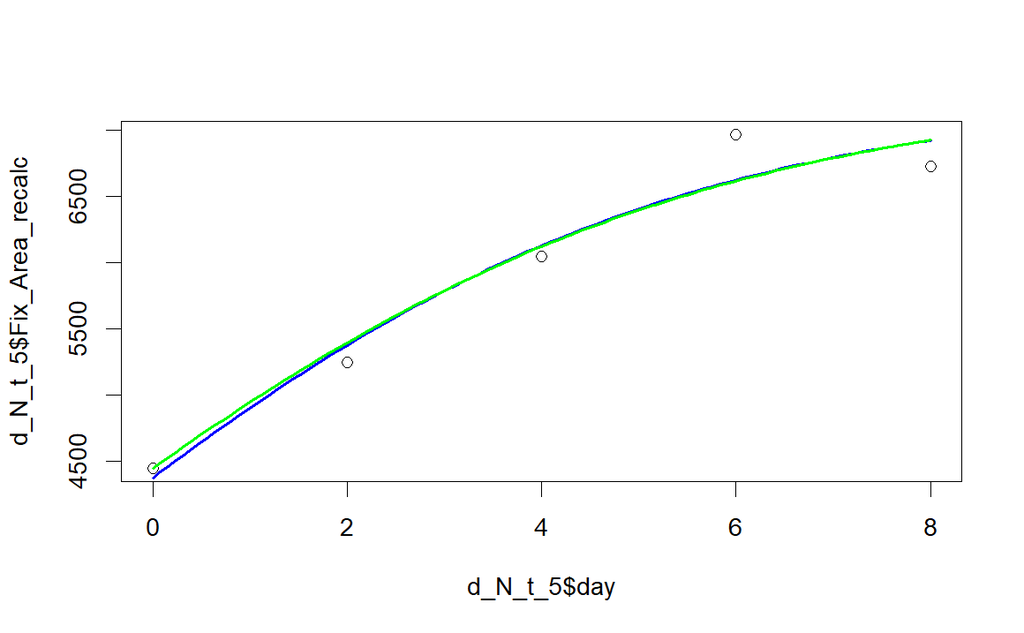

```r
curve( coef(fit_limit5_l)[["K"]] / (1 + (coef(fit_limit5_l)[["K"]]/d_N_t_5$Fix_Area_recalc[1] - 1) * exp(- coef(fit_limit5_l)[["r"]] * x )),
      add = TRUE, lwd = 2, col = "green")
```

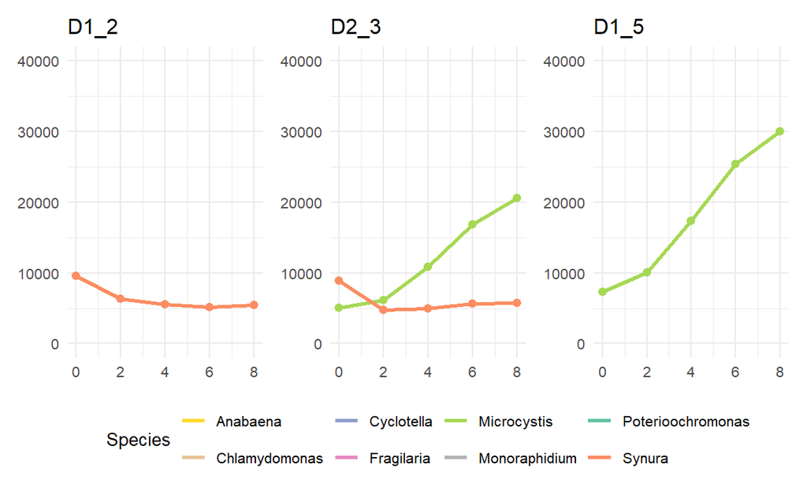

```r
((Npulse_sumplots[["1"]][["D1_2"]] + ylim(0,40000))|(Npulse_sumplots[["2"]][["D2_3"]] + ylim(0,40000))|(Npulse_sumplots[["1"]][["D1_5"]]) + ylim(0,40000))+
plot_layout(guides = 'collect') &
  theme(legend.position = "bottom")
```

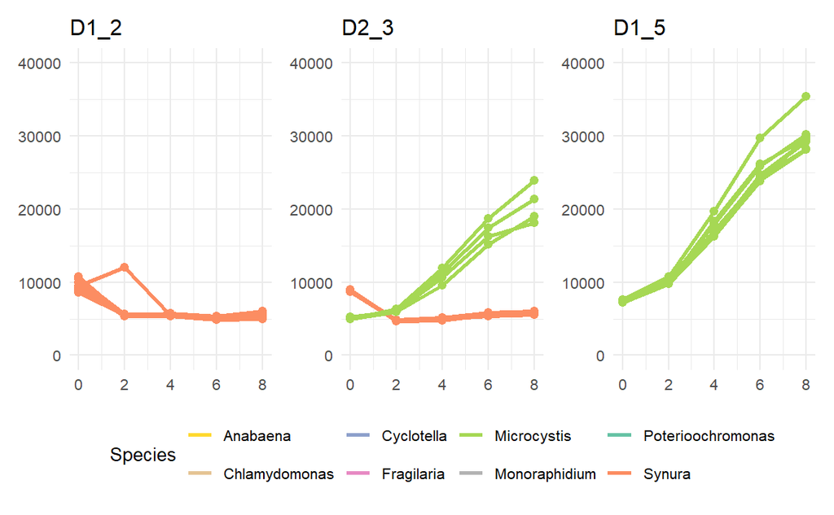

```r
((Npulse_plots[["1"]][["D1_2"]] + ylim(0,40000))|(Npulse_plots[["2"]][["D2_3"]] + ylim(0,40000))|(Npulse_plots[["1"]][["D1_5"]]) + ylim(0,40000))+
plot_layout(guides = 'collect') &
  theme(legend.position = "bottom")
```

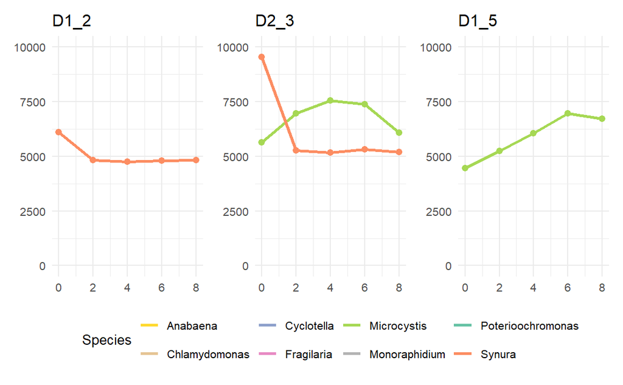

```r
((Nlimited_sumplots[["1"]][["D1_2"]] + ylim(0,10000))|(Nlimited_sumplots[["2"]][["D2_3"]] + ylim(0,10000))|(Nlimited_sumplots[["1"]][["D1_5"]]) + ylim(0,10000))+
plot_layout(guides = 'collect') &
  theme(legend.position = "bottom")
```

```r
df_2_total <- Npulse_list[["1"]][["D1_2"]][c("day","Fix_Area_recalc")]
fit2_all <- nls(
  Fix_Area_recalc ~ K / (1 + A * exp(-r * day )),
  data = df_2_total,
  start = list(
    K = 42000,
    r = 0.5,
    A = -0.45
    ),
  control = nls.control(maxiter = 100, warnOnly = TRUE)
)

summary(fit2)
```

```
Formula: Fix_Area_recalc ~ K/(1 + A * exp(-r * day))

Parameters:
    Estimate Std. Error t value Pr(>|t|)
K 5215.62184  170.11494  30.659  0.00106 **
r    0.50797    0.11304   4.494  0.04612 *
A   -0.45576    0.02048 -22.250  0.00201 **
---
Signif. codes:  0 ‘***’ 0.001 ‘**’ 0.01 ‘*’ 0.05 ‘.’ 0.1 ‘ ’ 1

Residual standard error: 191.7 on 2 degrees of freedom

Number of iterations to convergence: 5
Achieved convergence tolerance: 1.674e-06
```

```r
summary(fit2_all)
```

```
Formula: Fix_Area_recalc ~ K/(1 + A * exp(-r * day))

Parameters:
    Estimate Std. Error t value Pr(>|t|)
K 5215.62650  338.26445   15.42  < 2e-16 ***
r    0.50797    0.22477    2.26   0.0298 *
A   -0.45576    0.04073  -11.19 1.96e-13 ***
---
Signif. codes:  0 ‘***’ 0.001 ‘**’ 0.01 ‘*’ 0.05 ‘.’ 0.1 ‘ ’ 1

Residual standard error: 1078 on 37 degrees of freedom

Number of iterations to convergence: 4
Achieved convergence tolerance: 2.85e-06
```

# Interaction parameters

We have the data of co-cultivate of species 2 and 5. we consider the generalized Lotka-Volterra model:

$$\frac{\mathrm{d}N_{1}(t)}{\mathrm{d}t} = N_{1} ( r_{1} -
\alpha_{1,1}N_{1} - \alpha_{1,2}N_{2} )\\
\frac{\mathrm{d}N_{2}(t)}{\mathrm{d}t} = N_{2} ( r_{2} -
\alpha_{2,2}N_{2} - \alpha_{2,1}N_{1} )$$

We already get the $r_1$ and $r_2$ from the former inference of single species. For paramter $\alpha_{i,i}$ it is actually $r_i/K_i$. As a result, we only need to infer the parameter $\alpha_{1,2}$ and $\alpha_{2,1}$, which are the inter-species interaction strength.

We could also use the nonlinear least squares method. But this time, we should first use linear regression on the difference approximation of the data, to estimate a rough region of parameters. This step is done by hand in the former part, since parameters in logistic curve is quite obvious.

To simplify the model, as well as make the computation more efficient, we rescale the logistic model:

$$\frac{\mathrm{d}N}{\mathrm{d}t} = r N ( 1 - \frac{N}{K} )$$

Because of the significant different of $K$ for each species, directly using these values in gLV will makes the interaction a very small value, which is hard to evaluate. As a result, we rewrite it as:

$$\frac{\mathrm{d}N_{K}}{\mathrm{d}t} = r N_{K} ( 1 - N_{K} )\\
\frac{\mathrm{d}N_{rK}}{\mathrm{d}t} = N_{rK} ( r- N_{rK} )$$

where $N_{K} = N / K$,or , $N_{rK} = r N /K$, while $r$ kept the same. now all species are comparable. We use the rescaled population size to write the gLV:

$$\frac{\mathrm{d}N_{1}}{\mathrm{d}t} = N_{1} ( r_{1} - N_{1} -
\alpha_{1,2}N_{2} )\\
\frac{\mathrm{d}N_{2}}{\mathrm{d}t} = N_{2} ( r_{2} - N_{2} -
\alpha_{2,1}N_{1} )$$

```r
###
#observed data:
###
df_inter <- Npulse_sum[["2"]][["D2_3"]]
#t  <- c(0, 2, 4, 6, 8)
t <- df_inter[df_inter$species == species[2],]$day
N1 <- df_inter[df_inter$species == species[2],]$Fix_Area_recalc
N2 <- df_inter[df_inter$species == species[5],]$Fix_Area_recalc

r1 <- coef(fit2)[["r"]]
r2 <- coef(fit5)[["r"]]
K1 <- coef(fit2)[["K"]]
K2 <- coef(fit5)[["K"]]
N1 <- r1 * N1 / K1
N2 <- r2 * N2 / K2


###############################################
### difference linear regression
###############################################
dN1 <- diff(N1) / diff(t)
#dN1 <- c(dN1, dN1[length(dN1)])
M1 <- N1[-length(N1)] + diff(N1)/2

dN2 <- diff(N2) / diff(t)
#dN2 <- c(dN2, dN2[length(dN2)])
M2 <- N2[-length(N2)] + diff(N2)/2

x  <- M1 * M2
y1 <- r1*M1 - M1^2 - dN1
y2 <- r2*M2 - M2^2 - dN2

# linear regression
fit12 <- lm(y1 ~ 0 + x)
fit21 <- lm(y2 ~ 0 + x)

a12_init <- as.numeric(coef(fit12)[1])
a21_init <- as.numeric(coef(fit21)[1])

summary(fit12)
```

```
Call:
lm(formula = y1 ~ 0 + x)

Residuals:
       1        2        3        4
 0.09948  0.01199 -0.02928 -0.02034

Coefficients:
  Estimate Std. Error t value Pr(>|t|)
x -0.08902    0.48658  -0.183    0.867

Residual standard error: 0.0614 on 3 degrees of freedom
Multiple R-squared:  0.01103,   Adjusted R-squared:  -0.3186
F-statistic: 0.03347 on 1 and 3 DF,  p-value: 0.8665
```

```r
summary(fit21)
```

```
Call:
lm(formula = y2 ~ 0 + x)

Residuals:
        1         2         3         4
 0.006637 -0.004077 -0.006187  0.003453

Coefficients:
  Estimate Std. Error t value Pr(>|t|)
x  0.12502    0.04817   2.595   0.0807 .
---
Signif. codes:  0 ‘***’ 0.001 ‘**’ 0.01 ‘*’ 0.05 ‘.’ 0.1 ‘ ’ 1

Residual standard error: 0.006079 on 3 degrees of freedom
Multiple R-squared:  0.6918,    Adjusted R-squared:  0.5891
F-statistic: 6.734 on 1 and 3 DF,  p-value: 0.08072
```

```r
estimate_initial_interaction <- function(t,N1,N2,r1,r2){

  ###############################################
  ### difference linear regression
  ###############################################
  dN1 <- diff(N1) / diff(t)
  M1 <- N1[-length(N1)] + diff(N1)/2
  dN2 <- diff(N2) / diff(t)
  M2 <- N2[-length(N2)] + diff(N2)/2

  x  <- M1 * M2
  y1 <- r1*M1 - M1^2 - dN1
  y2 <- r2*M2 - M2^2 - dN2

  # linear regression
  fit12 <- lm(y1 ~ 0 + x)
  fit21 <- lm(y2 ~ 0 + x)

  return(list(fit12,fit21))
}
```

```r
gLV <- function(t, y, params) {
    n1 <- y[1]; n2 <- y[2]
    a12 <- params["a12"]
    a21 <- params["a21"]

    dn1 <- r1*n1 - n1*n1 - a12*n1*n2
    dn2 <- r2*n2 - n2*n2 - a21*n1*n2

    list(c(dn1, dn2))
}

estimate_nls_interaction <- function(t,N1,N2,r1,r2, a12_init, a21_init){

  ###############################################
  ### nls + ODE（deSolve）
  ###############################################

  simulate_gLV <- function(a12, a21) {
    params <- c(a12=a12, a21=a21)
    y0 <- c(N1[1], N2[1])
    out <- ode(y=y0, times=t, func=gLV, parms=params)
    return(out[,2:3])
  }

  residual_fn <- function(p) {
    a12 <- p[1]; a21 <- p[2]
    pred <- simulate_gLV(a12, a21)
    res <- c(pred[,1] - N1, pred[,2] - N2)
    return(res)
  }

  obj_fn <- function(p) sum(residual_fn(p)^2)

  p0 <- c(a12_init, a21_init)

  fit <- optim(p0, obj_fn)

  return(fit)
}
```

```r
df_inter<-Npulse_sum[["2"]][["D2_3"]]
df_inter1 <- df_inter[df_inter$species == species[2],]
df_inter2 <- df_inter[df_inter$species == species[5],]

t <- df_inter1$day
N1 <- df_inter1$Fix_Area_recalc
N2 <- df_inter2$Fix_Area_recalc
r1 <- coef(fit2)[["r"]]
r2 <- coef(fit5)[["r"]]
K1 <- coef(fit2)[["K"]]
K2 <- coef(fit5)[["K"]]
N1 <- r1 * N1 / K1
N2 <- r2 * N2 / K2

pulse_fit_inter <- estimate_initial_interaction(t,N1,N2,r1,r2)

pulse_a12_init <- as.numeric(coef(pulse_fit_inter[[1]])[1])
pulse_a21_init <- as.numeric(coef(pulse_fit_inter[[2]])[1])

pulse_nls_inter <- estimate_nls_interaction(t,N1,N2,r1,r2, pulse_a12_init,pulse_a21_init)

summary(pulse_fit_inter[[1]])
```

```
Call:
lm(formula = y1 ~ 0 + x)

Residuals:
       1        2        3        4
 0.09948  0.01199 -0.02928 -0.02034

Coefficients:
  Estimate Std. Error t value Pr(>|t|)
x -0.08902    0.48658  -0.183    0.867

Residual standard error: 0.0614 on 3 degrees of freedom
Multiple R-squared:  0.01103,   Adjusted R-squared:  -0.3186
F-statistic: 0.03347 on 1 and 3 DF,  p-value: 0.8665
```

```r
summary(pulse_fit_inter[[2]])
```

```
Call:
lm(formula = y2 ~ 0 + x)

Residuals:
        1         2         3         4
 0.006637 -0.004077 -0.006187  0.003453

Coefficients:
  Estimate Std. Error t value Pr(>|t|)
x  0.12502    0.04817   2.595   0.0807 .
---
Signif. codes:  0 ‘***’ 0.001 ‘**’ 0.01 ‘*’ 0.05 ‘.’ 0.1 ‘ ’ 1

Residual standard error: 0.006079 on 3 degrees of freedom
Multiple R-squared:  0.6918,    Adjusted R-squared:  0.5891
F-statistic: 6.734 on 1 and 3 DF,  p-value: 0.08072
```

```r
pulse_nls_inter$par
```

```
[1] -0.001995256  0.130470828
```

```r
pulse_a12_hat <- pulse_nls_inter$par[1]
pulse_a21_hat <- pulse_nls_inter$par[2]
```

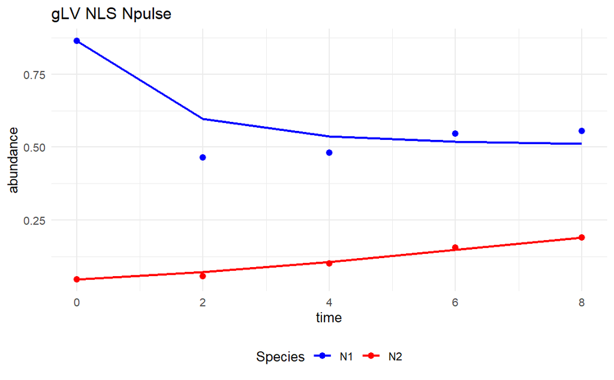

```r
simulate_gLV <- function(a12, a21) {
    params <- c(a12=a12, a21=a21)
    y0 <- c(N1[1], N2[1])
    out <- ode(y=y0, times=t, func=gLV, parms=params)
    return(out[,2:3])
}

pred <- simulate_gLV(pulse_a12_hat, pulse_a21_hat)

df <- data.frame(
  time = rep(t, 4),
  abundance = c(N1, pred[,1], N2, pred[,2]),
  type = factor(rep(c("N1 obs", "N1 fit", "N2 obs", "N2 fit"),
                    each = length(t))),
  species = rep(c("N1", "N1", "N2", "N2"), each = length(t))
)

# 为 obs/fit 区分点和线
df$mode <- ifelse(grepl("obs", df$type), "obs", "fit")

# 绘图
p_inter25_pulse <- ggplot(df, aes(x = time, y = abundance, color = species)) +
  # 实测点
  geom_point(data = subset(df, mode == "obs"), size = 2) +
  # 拟合线
  geom_line(data = subset(df, mode == "fit"), linewidth = 1) +
  labs(
    title = "gLV NLS Npulse",
    x = "time",
    y = "abundance",
    color = "Species"
  ) +
  scale_color_manual(values = c("N1" = "blue", "N2" = "red")) +
  theme_minimal() +
  theme(
    legend.position = "bottom"
  )

print(p_inter25_pulse)
```

```r
df_inter<-Nlimited_sum[["2"]][["D2_3"]]
df_inter1 <- df_inter[df_inter$species == species[2],]
df_inter2 <- df_inter[df_inter$species == species[5],]
t <- df_inter1$day
N1 <- df_inter1$Fix_Area_recalc
N2 <- df_inter2$Fix_Area_recalc
r1 <- coef(fit_limit2)[["r"]]
r2 <- coef(fit_limit5)[["r"]]
K1 <- coef(fit_limit2)[["K"]]
K2 <- coef(fit_limit5)[["K"]]
N1 <- r1 * N1 / K1
N2 <- r2 * N2 / K2

limited_fit_inter <- estimate_initial_interaction(t,N1,N2,r1,r2)

limit_a12_init <- as.numeric(coef(limited_fit_inter[[1]])[1])
limit_a21_init <- as.numeric(coef(limited_fit_inter[[2]])[1])

limit_nls_inter <- estimate_nls_interaction(t,N1,N2,r1,r2, limit_a12_init,limit_a21_init)

summary(limited_fit_inter[[1]])
```

```
Call:
lm(formula = y1 ~ 0 + x)

Residuals:
      1       2       3       4
-0.7864  0.3549  0.3253  0.2978

Coefficients:
  Estimate Std. Error t value Pr(>|t|)
x  -1.0974     0.4793  -2.289    0.106

Residual standard error: 0.5594 on 3 degrees of freedom
Multiple R-squared:  0.636, Adjusted R-squared:  0.5147
F-statistic: 5.242 on 1 and 3 DF,  p-value: 0.106
```

```r
summary(limited_fit_inter[[2]])
```

```
Call:
lm(formula = y2 ~ 0 + x)

Residuals:
        1         2         3         4
-0.017142 -0.012457  0.001443  0.034461

Coefficients:
   Estimate Std. Error t value Pr(>|t|)
x 0.0006912  0.0200245   0.035    0.975

Residual standard error: 0.02337 on 3 degrees of freedom
Multiple R-squared:  0.000397,  Adjusted R-squared:  -0.3328
F-statistic: 0.001192 on 1 and 3 DF,  p-value: 0.9746
```

```r
limit_nls_inter$par
```

```
[1] -0.51443631 -0.00219877
```

```r
limit_a12_hat <- limit_nls_inter$par[1]
limit_a21_hat <- limit_nls_inter$par[2]
```

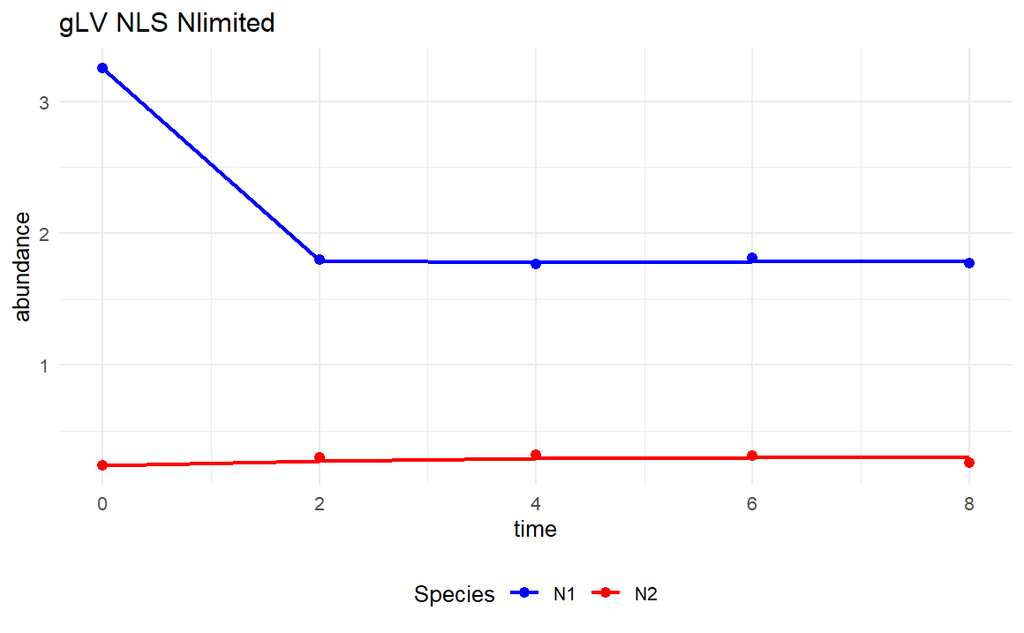

```r
simulate_gLV <- function(a12, a21) {
    params <- c(a12=a12, a21=a21)
    y0 <- c(N1[1], N2[1])
    out <- ode(y=y0, times=t, func=gLV, parms=params)
    return(out[,2:3])
}

pred <- simulate_gLV(limit_a12_hat, limit_a21_hat)

df <- data.frame(
  time = rep(t, 4),
  abundance = c(N1, pred[,1], N2, pred[,2]),
  type = factor(rep(c("N1 obs", "N1 fit", "N2 obs", "N2 fit"),
                    each = length(t))),
  species = rep(c("N1", "N1", "N2", "N2"), each = length(t))
)

# 为 obs/fit 区分点和线
df$mode <- ifelse(grepl("obs", df$type), "obs", "fit")

# 绘图
p_inter25_limited <- ggplot(df, aes(x = time, y = abundance, color = species)) +
  # 实测点
  geom_point(data = subset(df, mode == "obs"), size = 2) +
  # 拟合线
  geom_line(data = subset(df, mode == "fit"), linewidth = 1) +
  labs(
    title = "gLV NLS Nlimited",
    x = "time",
    y = "abundance",
    color = "Species"
  ) +
  scale_color_manual(values = c("N1" = "blue", "N2" = "red")) +
  theme_minimal() +
  theme(
    legend.position = "bottom"
  )

print(p_inter25_limited)
```

we then change back:

now the functions are

$$\frac{\mathrm{d}N_{1}}{\mathrm{d}t} = N_{1} ( r_{1} - N_{1} -
\alpha_{1,2}N_{2} )\\
\frac{\mathrm{d}N_{2}}{\mathrm{d}t} = N_{2} ( r_{2} - N_{2} -
\alpha_{2,1}N_{1} )$$

where $N1,N2$ are $N_{rK} = r N_{K}$.

$$\frac{\mathrm{d}N_{1}/r_1}{\mathrm{d}t} = N_{1}/r_1 ( r_{1} - r_1
N_{1}/r_1 - r_1 r_2 \alpha_{1,2} N_{2}/(r_1 r_2) )\\
\Rightarrow \frac{\mathrm{d}N_{1}}{\mathrm{d}t} = r_{1}N_{1} ( 1 - N_{1}
- r_{2}/r_{1} \alpha_{1,2} N_{2} )
\\
\frac{\mathrm{d}N_{2}}{\mathrm{d}t} = r_{2} N_{2} ( 1 - N_{2} -
r_{1}/r_{2} \alpha_{2,1}N_{1} )$$

As a result, we write $\alpha_{1,2} = \frac{r_2}{r_1}\alpha_{1,2}$, $\alpha_{2,1} = \frac{r_1}{r_2}\alpha_{2,1}$,

At the positive stable equilibrium, we have:

$$r_{1} - N^*_{1} - \alpha_{1,2} N^*_{2} = 0\\
r_{2} - N^*_{2} - \alpha_{2,1} N^*_{1} = 0$$

As a result, we could solve:

$$N^*_{1} = \frac{r_{1} - \alpha_{1,2}r_{2}}{1 - \alpha_{1,2}
\alpha_{2,1}}\\
N^*_{2} = \frac{r_{2} - \alpha_{2,1}r_{1}}{1 - \alpha_{1,2}
\alpha_{2,1}}$$

To make sure $N^*>0$, with the condition that $1-\alpha_{1,2}\alpha{2,1} >0$, we need to make sure

$$r_{1} - \alpha_{1,2}r_{2}>0\\
r_{2} - \alpha_{2,1}r_{1}>0$$

This region is the feasible domain of $r_1,r_2$ here.

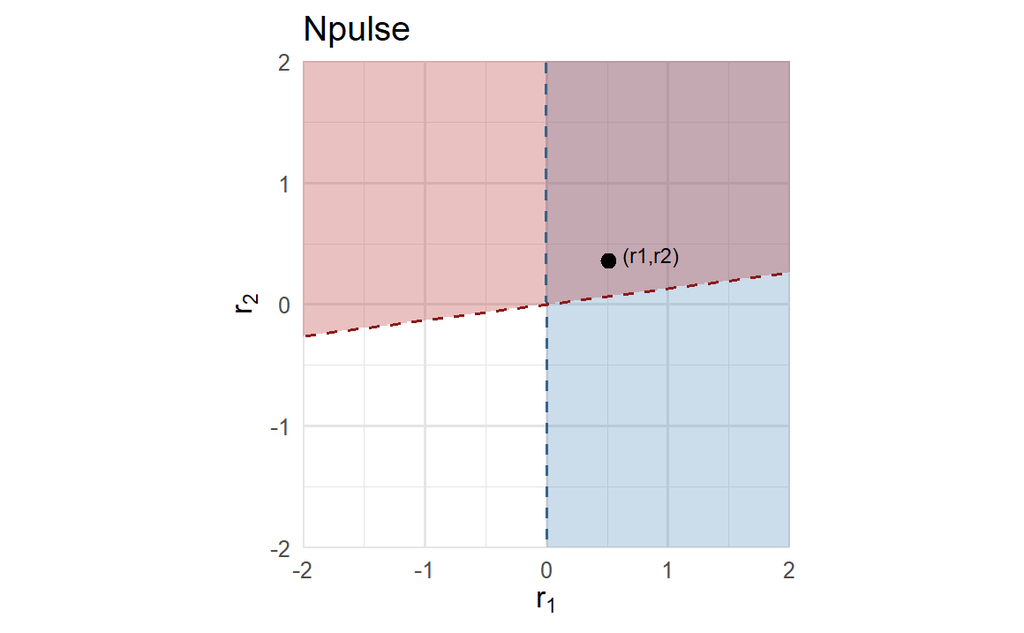

```r
a12 <- pulse_a12_hat
a21 <- pulse_a21_hat

# 网格分辨率（越小越精细，但越慢）
step <- 0.01

# r1,r2 范围
r1_seq <- seq(-2, 2, by = step)
r2_seq <- seq(-2, 2, by = step)

# 生成网格并计算不等式
grid <- expand.grid(r1 = r1_seq, r2 = r2_seq)
grid$cond1 <- with(grid, r1 > a12 * r2)      # r1 - a12*r2 > 0
grid$cond2 <- with(grid, r2 > a21 * r1)      # r2 - a21*r1 > 0

# 目标点
pt <- data.frame(r1 = as.numeric(coef(fit2)["r"]), r2 = as.numeric(coef(fit5)["r"]))

# 绘图
p_pulse <- ggplot() +
  # 条件1 的区域（半透明蓝）
  geom_tile(
    data = subset(grid, cond1),
    aes(x = r1, y = r2),
    fill = "steelblue",
    alpha = 0.28
  ) +
  # 条件2 的区域（半透明红）
  geom_tile(
    data = subset(grid, cond2),
    aes(x = r1, y = r2),
    fill = "firebrick",
    alpha = 0.28
  ) +
  # 边界直线： r1 = a12 * r2 -> r2 = r1 / a12
  geom_abline(slope = 1 / a12, intercept = 0, color = "steelblue4", linetype = "dashed") +
  # 边界直线： r2 = a21 * r1 -> slope = a21
  geom_abline(slope = a21, intercept = 0, color = "firebrick4", linetype = "dashed") +
  # 标注目标点
  geom_point(data = pt, aes(x = r1, y = r2), color = "black", size = 3) +
  geom_text(data = pt, aes(x = r1, y = r2, label = "(r1,r2)"),
            nudge_x = 0.12, nudge_y = 0.05, size = 3.5, hjust = 0) +
  coord_equal(xlim = c(-2, 2), ylim = c(-2, 2), expand = FALSE) +
  labs(
    #title = expression("Regions: " ~ r[1] - alpha[1,2] * r[2] > 0 ~ "  and  " ~ r[2] - alpha[2,1] * r[1] > 0),
    title = "Npulse",
    x = expression(r[1]),
    y = expression(r[2])
  ) +
  theme_minimal(base_size = 14) +
  theme(
    panel.grid = element_line(color = "grey90"),
    legend.position = "none"
  )

print(p_pulse)
```

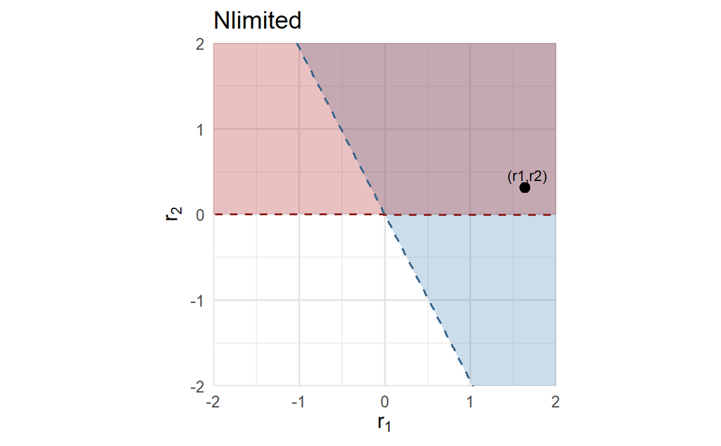

```r
a12 <- limit_a12_hat
a21 <- limit_a21_hat

# 网格分辨率（越小越精细，但越慢）
step <- 0.01

# r1,r2 范围
r1_seq <- seq(-2, 2, by = step)
r2_seq <- seq(-2, 2, by = step)

# 生成网格并计算不等式
grid <- expand.grid(r1 = r1_seq, r2 = r2_seq)
grid$cond1 <- with(grid, r1 > a12 * r2)      # r1 - a12*r2 > 0
grid$cond2 <- with(grid, r2 > a21 * r1)      # r2 - a21*r1 > 0

# 目标点
pt <- data.frame(r1 = as.numeric(coef(fit_limit2)["r"]), r2 = as.numeric(coef(fit_limit5)["r"]))

# 绘图
p_limited <- ggplot() +
  # 条件1 的区域（半透明蓝）
  geom_tile(
    data = subset(grid, cond1),
    aes(x = r1, y = r2),
    fill = "steelblue",
    alpha = 0.28
  ) +
  # 条件2 的区域（半透明红）
  geom_tile(
    data = subset(grid, cond2),
    aes(x = r1, y = r2),
    fill = "firebrick",
    alpha = 0.28
  ) +
  # 边界直线： r1 = a12 * r2 -> r2 = r1 / a12
  geom_abline(slope = 1 / a12, intercept = 0, color = "steelblue4", linetype = "dashed") +
  # 边界直线： r2 = a21 * r1 -> slope = a21
  geom_abline(slope = a21, intercept = 0, color = "firebrick4", linetype = "dashed") +
  # 标注目标点
  geom_point(data = pt, aes(x = r1, y = r2), color = "black", size = 3) +
  geom_text(data = pt, aes(x = r1, y = r2, label = "(r1,r2)"),
            nudge_x = -0.2, nudge_y = 0.15, size = 3.5, hjust = 0) +
  coord_equal(xlim = c(-2, 2), ylim = c(-2, 2), expand = FALSE) +
  labs(
    #title = expression("Regions: " ~ r[1] - alpha[1,2] * r[2] > 0 ~ "  and  " ~ r[2] - alpha[2,1] * r[1] > 0),
    title = "Nlimited",
    x = expression(r[1]),
    y = expression(r[2])
  ) +
  theme_minimal(base_size = 14) +
  theme(
    panel.grid = element_line(color = "grey90"),
    legend.position = "none"
  )

print(p_limited)
```

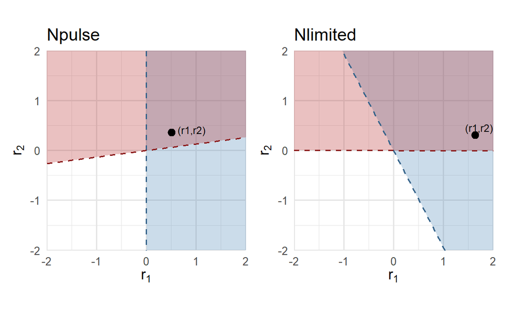

```r
p_pulse | p_limited
```